# Analise INSE 2021 por Vinicius Ferreira dos Santos

Vinicius Ferreira Git-VFS10 Insta-Vinifersan89

2024-05-23

### Objetivo !

Neste relatório iremos Analise o Nível SocioEconômico Brasileiro de 2021 (INSE)

### Oque é o INSE ?

**O Indicador de Nível Socioeconômico (Inse) é uma medida utilizada para classificar as escolas públicas do Brasil.** O Inse é calculado com base em dados do Censo Escolar, como a escolaridade dos pais, a posse de bens e serviços da família e o acesso à internet.

**O Inse é usado para contextualizar o desempenho das escolas nas avaliações e exames realizados pelo Instituto Nacional de Estudos e Pesquisas Educacionais Anísio Teixeira (Inep).** Isso permite que o Inep compare o desempenho das escolas de diferentes níveis socioeconômicos e identifique as escolas que precisam de mais apoio.

*O Inse é uma ferramenta importante para a melhoria da educação no Brasil.* Ele ajuda a identificar as escolas que precisam de mais apoio e permite que o INEP desenvolva políticas públicas para melhorar a educação de todos os alunos, independentemente de sua origem social.

*OS dados de INSE são providenciados pelo Sistema Nacional de Avaliação da Educação Básica (Saeb).*

**O Sistema Nacional de Avaliação da Educação Básica (SAEB) é um sistema de avaliação externa em larga escala, composto por um conjunto de instrumentos, realizado periodicamente pelo Instituto Nacional de Estudos e Pesquisas Educacionais Anísio Teixeira (INEP),** desde os anos 1990, e tem por objetivos, no âmbito da educação básica: (I) produzir indicadores educacionais para o Brasil, suas regiões e unidades da Federação e, quando possível, para os municípios e as instituições escolares, tendo em vista a manutenção da comparabilidade dos dados, permitindo, assim, o incremento das séries históricas; (II) avaliar a qualidade, a equidade e a eficiência da educação praticada no País em seus diversos níveis governamentais; (III) subsidiar a elaboração, o monitoramento e o aprimoramento de políticas públicas em educação baseadas em evidências, com vistas ao desenvolvimento social e econômico do Brasil; (IV) desenvolver competência técnica e científica na área de avaliação educacional, ativando o intercâmbio entre instituições de ensino e pesquisa (Brasil. Inep, 2021b).

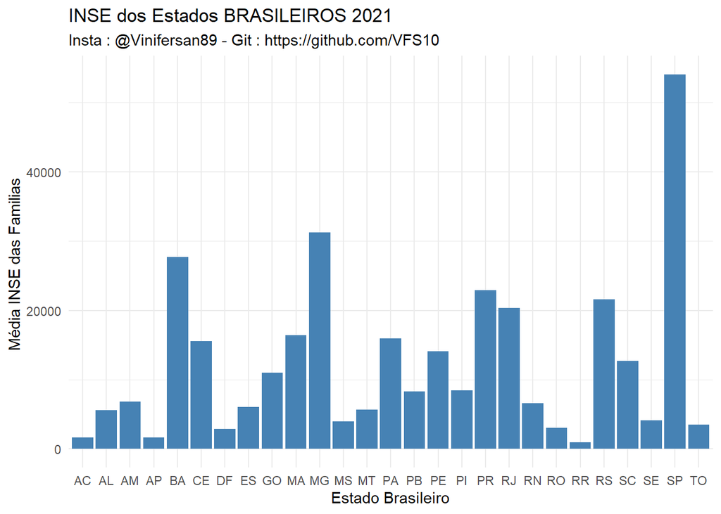

**Total de alunos por estado**

Plotando nosso grafico de barras, identificamos que o estado com maior número de alunos é o estado de Sào Paulo (SP) seguido de Minas Gerais (MG).

Com base nos dados, conseguimos identificar que a maior parte das familias com filhos em escolas estão em São Paulo, também identificamos uma maior demanda de professores e necessidade de investimento em edução nesse estado,a principio apelas pelo número de crianças

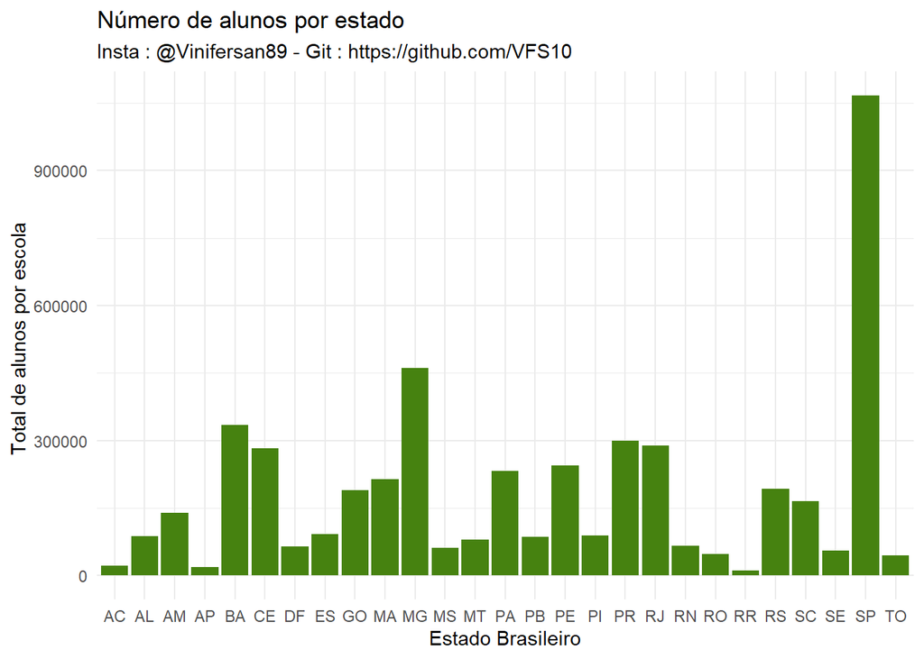

**Resumo estatistico da media do INSE do estado de SP e MG**

São Paulo

```
##    MEDIA_INSE
##  Min.   :4.030
##  1st Qu.:5.100
##  Median :5.260
##  Mean   :5.271
##  3rd Qu.:5.440
##  Max.   :6.720
```

Minas Gerais

```
##    MEDIA_INSE
##  Min.   :3.380
##  1st Qu.:4.730
##  Median :5.010
##  Mean   :4.962
##  3rd Qu.:5.220
##  Max.   :6.340
```

**Analisando o INSE do estado de SP**

Como eu Vinicius Ferreira dos Santos sou aqui de São Bernardo do Campo - São Paulo . Iremos focar nossa Análise nessa região, sendo mais especifico ABC **Vamos juntos !!!**

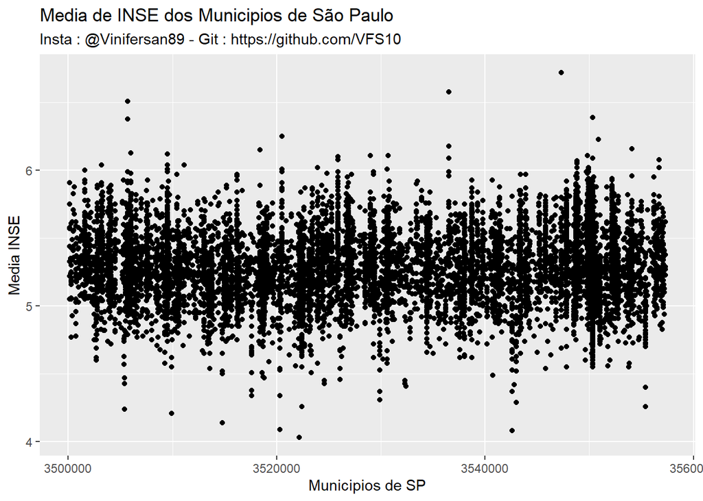

**Média dos Municipios do Grande ABC**

Algo interessante que podemos comentar entre **São Bernaro do Campo e São Caetano do Sul**, e que também influencia em nossa análise é a diferença do número de habitantes entre as duas cidades, São Bernardo do Campo com seus 810 729 habitantes e São Caetano do Sul 161.957 habitantes (Dados extraidos do Wikipédia).

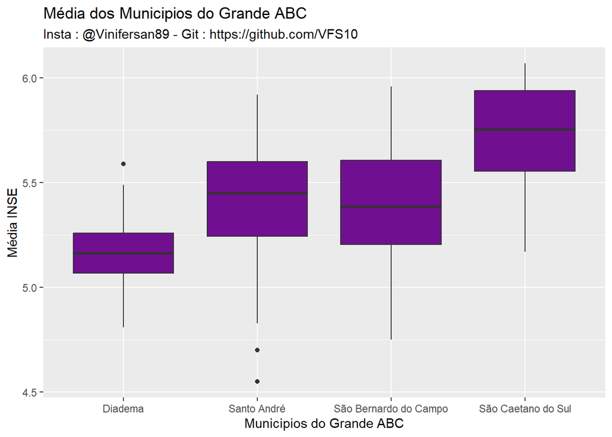

*Escolas do Municipio de São Bernardo do Campo*

Como estou localizado no municipio de São Bernardo do Campo, irei focar no mesmo , nada impede de no futuro verificarmos também as demais cidades !

Em uma breve visualização identificamos que as escolas de SBC, estão entre 4,5 e 6 no Nivel Ecônomico Brasileiro,a grande maioria se encontra a Baixo de 6. Não irei apresentar o nome dessas escolas diretamente nessa visualização, devido a quantidade os nomes não ficariam legiveis no gráfico.

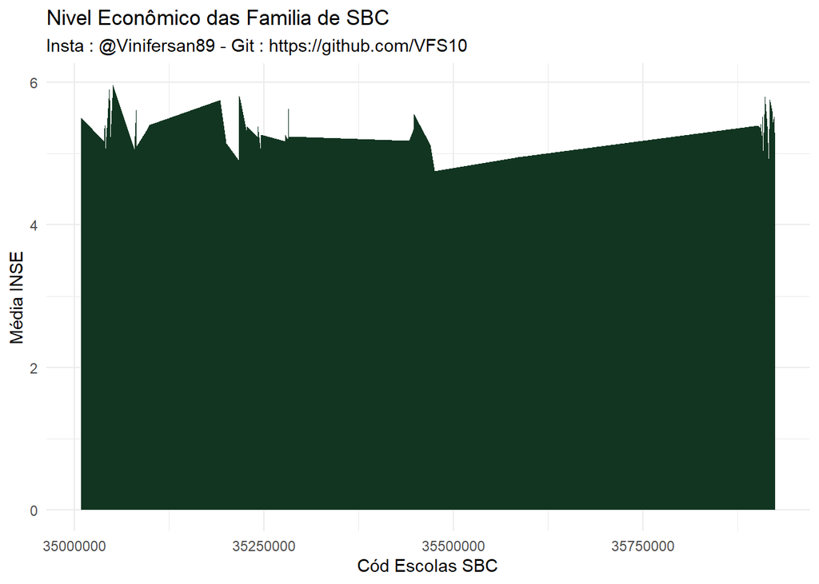

Vamos dar continuidade encontrando as Escolas/Familias de São Bernardo do Campo que estão abaixo do limite SocioEconômico inferior, estas escolas/familias necessitam de uma atenção/estudo de caso em especial !

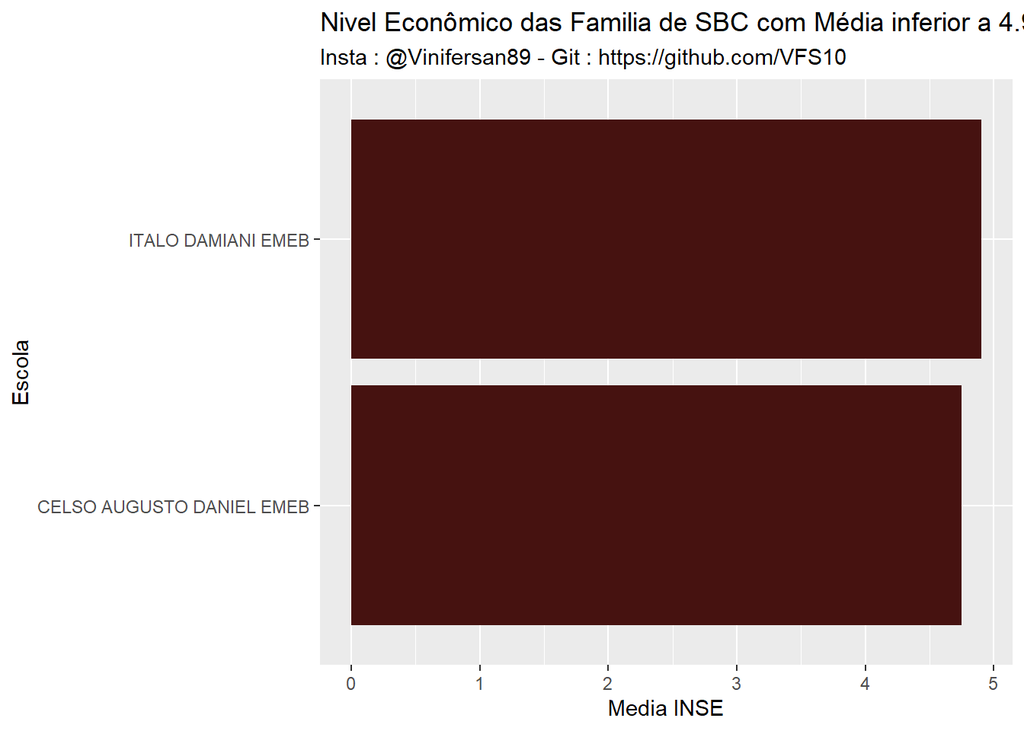

OBS: este é um breve portfolio do meu aprendizado e evolução no R. Podemos analisar mais a fundo essas informações dependendo da necessidade do negócio.